# Statistical Analysis of Physical Characteristics of Palmer Penguins

Ketaki Patil

2026-09-12

# 1 Introduction

The Palmer Penguins dataset contains 344 observations from Adelie, Chinstrap and Gentoo penguins. This report investigates differences in body mass and flipper length across species and sex using descriptive statistics, hypothesis testing, effect size, ANOVA, Tukey HSD and Kruskal-Wallis tests.

# 2 Data and Packages

```r
pkgs <- c('palmerpenguins','dplyr','ggplot2','moments','car')
miss <- pkgs[!pkgs %in% rownames(installed.packages())]
if(length(miss)) install.packages(miss, repos='https://cloud.r-project.org')
lapply(pkgs, library, character.only=TRUE)
```

[output not shown]

```r
penguins <- palmerpenguins::penguins
```

The dataset contains 344 observations.

# 3 Descriptive Statistics

```r
desc <- function(x){x<-x[!is.na(x)]; data.frame(N=length(x),Mean=mean(x),Median=median(x),Minimum=min(x),Maximum=max(x),Variance=var(x),SD=sd(x),Q1=quantile(x,.25,names=FALSE),Q3=quantile(x,.75,names=FALSE),IQR=IQR(x),Skewness=moments::skewness(x),Kurtosis=moments::kurtosis(x))}
knitr::kable(round(desc(penguins$body_mass_g),3))
```

| N | Mean | Median | Minimum | Maximum | Variance | SD | Q1 | Q3 | IQR | Skewness | Kurtosis |
| --- | --- | --- | --- | --- | --- | --- | --- | --- | --- | --- | --- |
| 342 | 4201.754 | 4050 | 2700 | 6300 | 643131.1 | 801.955 | 3550 | 4750 | 1200 | 0.468 | 2.274 |

```r
species_desc <- penguins %>% group_by(species) %>% summarise(N=sum(!is.na(body_mass_g)),Mean=mean(body_mass_g,na.rm=T),Median=median(body_mass_g,na.rm=T),Minimum=min(body_mass_g,na.rm=T),Maximum=max(body_mass_g,na.rm=T),Variance=var(body_mass_g,na.rm=T),SD=sd(body_mass_g,na.rm=T),Q1=quantile(body_mass_g,.25,na.rm=T,names=F),Q3=quantile(body_mass_g,.75,na.rm=T,names=F),IQR=IQR(body_mass_g,na.rm=T),Skewness=moments::skewness(body_mass_g,na.rm=T),Kurtosis=moments::kurtosis(body_mass_g,na.rm=T),.groups='drop')
knitr::kable(
  species_desc %>%
    mutate(across(where(is.numeric), ~ round(.x, 3)))
)
```

| species | N | Mean | Median | Minimum | Maximum | Variance | SD | Q1 | Q3 | IQR | Skewness | Kurtosis |
| --- | --- | --- | --- | --- | --- | --- | --- | --- | --- | --- | --- | --- |
| Adelie | 151 | 3700.662 | 3700 | 2850 | 4775 | 210282.9 | 458.566 | 3350.0 | 4000 | 650.0 | 0.282 | 2.406 |
| Chinstrap | 68 | 3733.088 | 3700 | 2700 | 4800 | 147713.5 | 384.335 | 3487.5 | 3950 | 462.5 | 0.242 | 3.464 |
| Gentoo | 123 | 5076.016 | 5000 | 3950 | 6300 | 254133.2 | 504.116 | 4700.0 | 5500 | 800.0 | 0.069 | 2.258 |

# 4 Visualizations

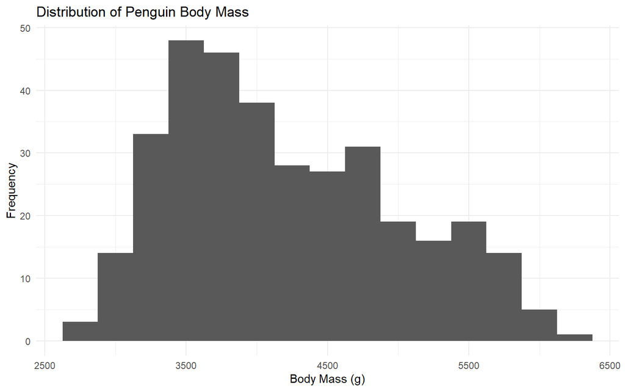

```r
ggplot(penguins,aes(body_mass_g))+geom_histogram(binwidth=250,na.rm=T)+labs(title='Distribution of Penguin Body Mass',x='Body Mass (g)',y='Frequency')+theme_minimal()
```

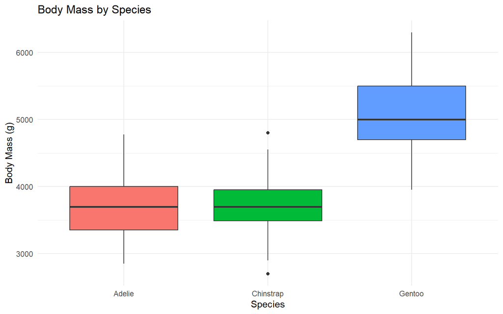

```r
ggplot(penguins,aes(species,body_mass_g,fill=species))+geom_boxplot(na.rm=T)+labs(title='Body Mass by Species',x='Species',y='Body Mass (g)')+theme_minimal()+theme(legend.position='none')
```

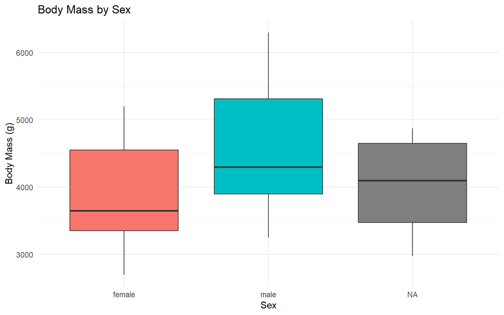

```r
ggplot(penguins,aes(sex,body_mass_g,fill=sex))+geom_boxplot(na.rm=T)+labs(title='Body Mass by Sex',x='Sex',y='Body Mass (g)')+theme_minimal()+theme(legend.position='none')
```

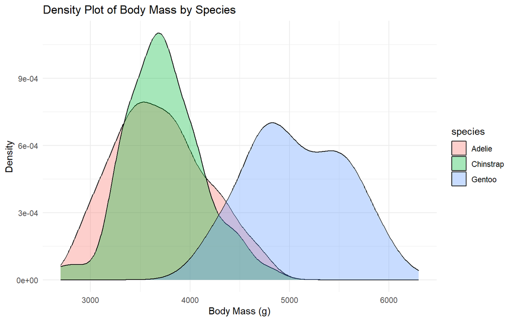

```r
ggplot(penguins,aes(body_mass_g,fill=species))+geom_density(alpha=.35,na.rm=T)+labs(title='Density Plot of Body Mass by Species',x='Body Mass (g)',y='Density')+theme_minimal()
```

# 5 Male vs Female Body Mass

**H0:** mean male body mass equals mean female body mass.  
**H1:** mean male body mass differs from mean female body mass.

```r
sexdat <- penguins %>% filter(!is.na(body_mass_g),!is.na(sex)) %>% droplevels()
male <- sexdat$body_mass_g[sexdat$sex=='male']; female <- sexdat$body_mass_g[sexdat$sex=='female']
shapiro.test(male); shapiro.test(female)
```

```
##
##  Shapiro-Wilk normality test
##
## data:  male
## W = 0.92504, p-value = 1.227e-07
```

```
##
##  Shapiro-Wilk normality test
##
## data:  female
## W = 0.91931, p-value = 6.155e-08
```

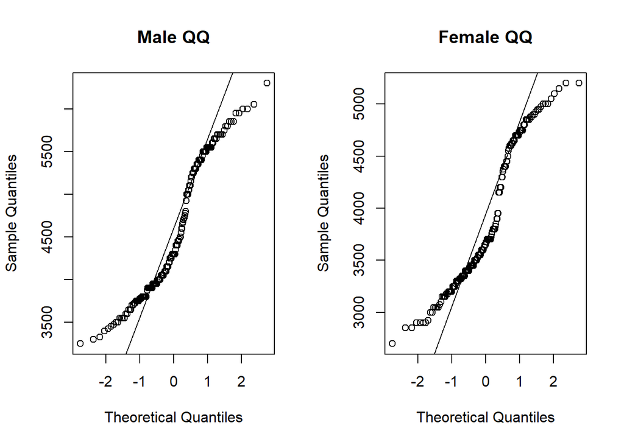

```r
par(mfrow=c(1,2)); qqnorm(male,main='Male QQ'); qqline(male); qqnorm(female,main='Female QQ'); qqline(female); par(mfrow=c(1,1))
```

```r
tt <- t.test(male,female,var.equal=FALSE,conf.level=.95); tt
```

```
##
##  Welch Two Sample t-test
##
## data:  male and female
## t = 8.5545, df = 323.9, p-value = 4.794e-16
## alternative hypothesis: true difference in means is not equal to 0
## 95 percent confidence interval:
##  526.2453 840.5783
## sample estimates:
## mean of x mean of y
##  4545.685  3862.273
```

```r
pooled_sd <- sqrt(((length(male)-1)*var(male)+(length(female)-1)*var(female))/(length(male)+length(female)-2))
d <- (mean(male)-mean(female))/pooled_sd
knitr::kable(data.frame(Male_Mean=mean(male),Female_Mean=mean(female),Difference=mean(male)-mean(female),CI_Low=tt$conf.int[1],CI_High=tt$conf.int[2],P_Value=tt$p.value,Cohens_d=d),digits=4)
```

| Male_Mean | Female_Mean | Difference | CI_Low | CI_High | P_Value | Cohens_d |
| --- | --- | --- | --- | --- | --- | --- |
| 4545.685 | 3862.273 | 683.4118 | 526.2453 | 840.5783 | 0 | 0.9362 |

# 6 One-Way ANOVA

The model is `body_mass_g ~ species`.

```r
anova_dat <- penguins %>% filter(!is.na(body_mass_g),!is.na(species)) %>% droplevels()
anova_dat %>% group_by(species) %>% summarise(W=unname(shapiro.test(body_mass_g)$statistic),p=shapiro.test(body_mass_g)$p.value,.groups='drop')
```

```
## # A tibble: 3 × 3
##   species       W      p
##   <fct>     <dbl>  <dbl>
## 1 Adelie    0.981 0.0324
## 2 Chinstrap 0.984 0.561
## 3 Gentoo    0.986 0.234
```

```r
car::leveneTest(body_mass_g~species,data=anova_dat)
```

```
## Levene's Test for Homogeneity of Variance (center = median)
##        Df F value   Pr(>F)
## group   2  5.1203 0.006445 **
##       339
## ---
## Signif. codes:  0 '***' 0.001 '**' 0.01 '*' 0.05 '.' 0.1 ' ' 1
```

```r
m1 <- aov(body_mass_g~species,data=anova_dat); summary(m1)
```

```
##              Df    Sum Sq  Mean Sq F value Pr(>F)
## species       2 146864214 73432107   343.6 <2e-16 ***
## Residuals   339  72443483   213698
## ---
## Signif. codes:  0 '***' 0.001 '**' 0.01 '*' 0.05 '.' 0.1 ' ' 1
```

```r
TukeyHSD(m1)
```

```
##   Tukey multiple comparisons of means
##     95% family-wise confidence level
##
## Fit: aov(formula = body_mass_g ~ species, data = anova_dat)
##
## $species
##                        diff       lwr       upr     p adj
## Chinstrap-Adelie   32.42598 -126.5002  191.3522 0.8806666
## Gentoo-Adelie    1375.35401 1243.1786 1507.5294 0.0000000
## Gentoo-Chinstrap 1342.92802 1178.4810 1507.3750 0.0000000
```

# 7 Kruskal-Wallis Test

```r
kruskal.test(body_mass_g~species,data=anova_dat)
```

```
##
##  Kruskal-Wallis rank sum test
##
## data:  body_mass_g by species
## Kruskal-Wallis chi-squared = 217.6, df = 2, p-value < 2.2e-16
```

The ANOVA and Kruskal-Wallis conclusions are compared to determine whether the species effect is robust to the choice of statistical method.

# 8 Two-Way ANOVA

The model `body_mass_g ~ species * sex` tests species, sex and the species-by-sex interaction.

```r
two_dat <- penguins %>% filter(!is.na(body_mass_g),!is.na(species),!is.na(sex)) %>% droplevels()
m2 <- aov(body_mass_g~species*sex,data=two_dat); summary(m2)
```

```
##              Df    Sum Sq  Mean Sq F value   Pr(>F)
## species       2 145190219 72595110 758.358  < 2e-16 ***
## sex           1  37090262 37090262 387.460  < 2e-16 ***
## species:sex   2   1676557   838278   8.757 0.000197 ***
## Residuals   327  31302628    95727
## ---
## Signif. codes:  0 '***' 0.001 '**' 0.01 '*' 0.05 '.' 0.1 ' ' 1
```

```r
shapiro.test(residuals(m2))
```

```
##
##  Shapiro-Wilk normality test
##
## data:  residuals(m2)
## W = 0.99776, p-value = 0.9367
```

```r
car::leveneTest(body_mass_g~interaction(species,sex),data=two_dat)
```

```
## Levene's Test for Homogeneity of Variance (center = median)
##        Df F value Pr(>F)
## group   5  1.3908 0.2272
##       327
```

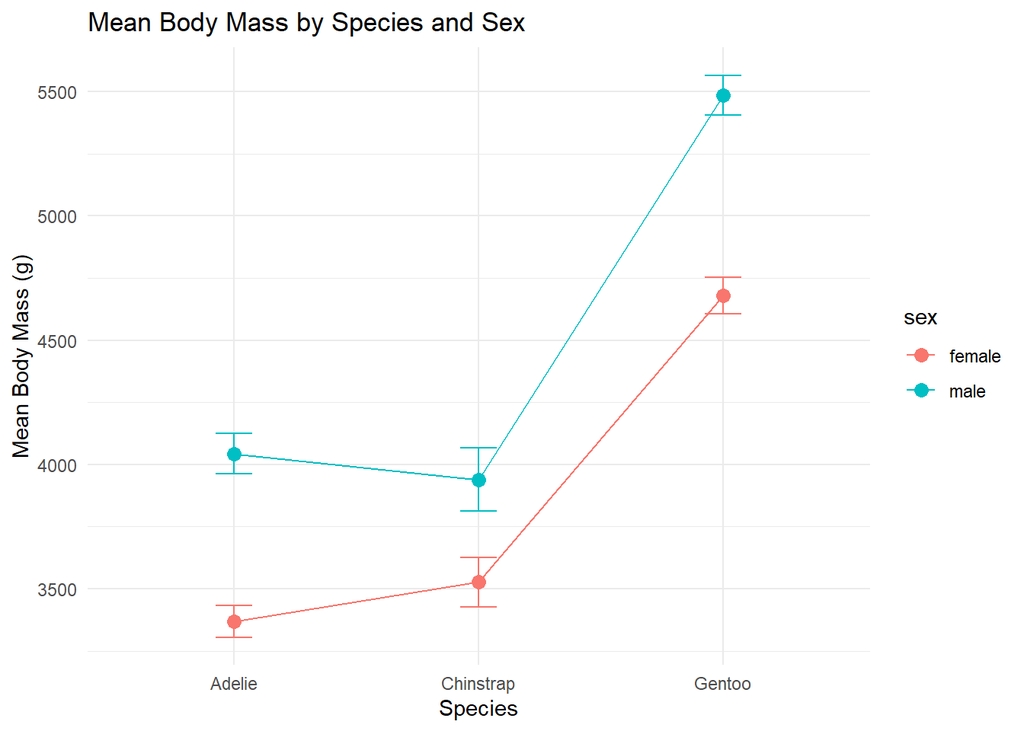

```r
ggplot(two_dat,aes(species,body_mass_g,color=sex,group=sex))+stat_summary(fun=mean,geom='point',size=3)+stat_summary(fun=mean,geom='line')+stat_summary(fun.data=mean_cl_normal,geom='errorbar',width=.15)+labs(title='Mean Body Mass by Species and Sex',x='Species',y='Mean Body Mass (g)')+theme_minimal()
```

# 9 Additional Analysis: Flipper Length

```r
flip <- penguins %>% filter(!is.na(flipper_length_mm),!is.na(species)) %>% droplevels()
fm <- aov(flipper_length_mm~species,data=flip); summary(fm)
```

```
##              Df Sum Sq Mean Sq F value Pr(>F)
## species       2  52473   26237   594.8 <2e-16 ***
## Residuals   339  14953      44
## ---
## Signif. codes:  0 '***' 0.001 '**' 0.01 '*' 0.05 '.' 0.1 ' ' 1
```

```r
TukeyHSD(fm)
```

```
##   Tukey multiple comparisons of means
##     95% family-wise confidence level
##
## Fit: aov(formula = flipper_length_mm ~ species, data = flip)
##
## $species
##                       diff       lwr       upr p adj
## Chinstrap-Adelie  5.869887  3.586583  8.153191     0
## Gentoo-Adelie    27.233349 25.334376 29.132323     0
## Gentoo-Chinstrap 21.363462 19.000841 23.726084     0
```

```r
kruskal.test(flipper_length_mm~species,data=flip)
```

```
##
##  Kruskal-Wallis rank sum test
##
## data:  flipper_length_mm by species
## Kruskal-Wallis chi-squared = 244.89, df = 2, p-value < 2.2e-16
```

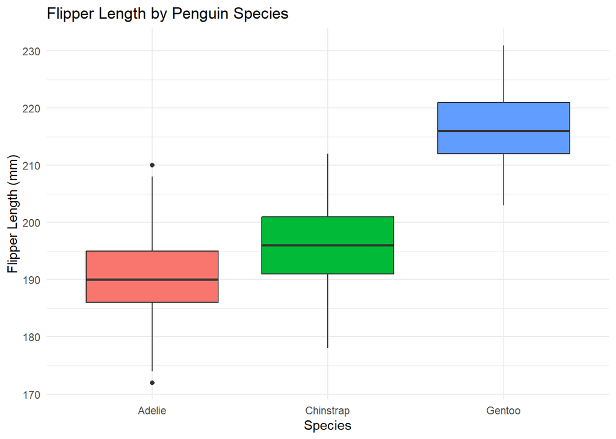

```r
ggplot(flip,aes(species,flipper_length_mm,fill=species))+geom_boxplot()+labs(title='Flipper Length by Penguin Species',x='Species',y='Flipper Length (mm)')+theme_minimal()+theme(legend.position='none')
```

# 10 Conclusion

The statistical analysis shows that penguin body mass differs significantly by sex and species. Male penguins had a higher mean body mass (4545.69 g) than female penguins (3862.27 g). The independent-samples t-test showed a highly significant difference between the two groups (t = 8.555, p < 0.001). The 95% confidence interval for the mean difference was 526.25 g to 840.58 g, and Cohen’s d was 0.936, indicating a large effect size.

The one-way ANOVA showed a significant difference in body mass among Adelie, Chinstrap, and Gentoo penguins, F(2, 339) = 343.6, p < 0.001. Tukey’s HSD showed that Gentoo penguins had significantly greater body mass than both Adelie and Chinstrap penguins, while the difference between Adelie and Chinstrap penguins was not significant. Levene’s test indicated unequal variances across species, so the non-parametric Kruskal-Wallis test was also performed. It confirmed a significant difference among species (χ²(2) = 217.599, p < 0.001).

The two-way ANOVA found significant effects of species and sex on body mass, as well as a significant species × sex interaction (p < 0.001). This indicates that the effect of sex on body mass differs across species.

Flipper length also differed significantly among the three species. One-way ANOVA showed a significant species effect, F(2, 339) = 594.8, p < 0.001. Tukey’s HSD indicated significant differences between every pair of species. The Kruskal-Wallis test also confirmed a significant difference in flipper length among species (χ²(2) = 244.89, p < 0.001).

Overall, the analysis demonstrates clear differences in physical characteristics among penguin species, with Gentoo penguins generally having greater body mass and longer flippers than Adelie and Chinstrap penguins.